# Assignment1.1

20020510 15mnb4

References: The Hourse data was downloaded from [kaggle] https://www.kaggle.com/c/house-prices-advanced-regression-techniques.

How to write an R Markdown document: http://rmarkdown.rstudio.com

## R for Data Science: https://r4ds.had.co.nz/index.html

The goals of this assignment: 1. Get familier with R studio. 2. Hands on R programming for data analysis.

Total points: 100

## Load libraries (10 points)

If you need to use any R package, add it to the below block. Note that you must install the package before using it.

```r
library(Hmisc)
library(GGally)
library(dplyr) # include the dplur library (pipe is used)
```

## Prepare dataset, complete the following five tasks (50 points)

1. Load data from the given csv file.
2. Report the number of data points in the given csv file.
3. Show the top 5 rows of the loaded dataset.
4. Randomly split the dataset into training and testing, training takes 80%.
5. Take the training data, summarize the data (call the describe function in Hmisc).

```r
housePriceData <- read.csv(file="C:\\Users\\Maeve Buchan\\Desktop\\housePriceData.csv", header=TRUE, sep=",")
numDataPoints <- nrow(housePriceData)
first5Rows <- head(housePriceData,5)
trainingData <- housePriceData %>% sample_frac(.8) # random selection of 80% of the data
testingData <- housePriceData[!housePriceData$Id %in% trainingData$Id,] # grabbing the compliment of the intersection of the housing data and training data
dataSumarization <- describe(housePriceData)

print(paste0("There are ",numDataPoints, " data objects, and ", numDataPoints*38, "value entries"))
```

```
## [1] "There are 1460 data objects, and 55480value entries"
```

```r
print(first5Rows)
```

```
##   Id MSSubClass MSZoning LotFrontage LotArea Street LotShape LandContour
## 1  1         60       RL          65    8450   Pave      Reg         Lvl
## 2  2         20       RL          80    9600   Pave      Reg         Lvl
## 3  3         60       RL          68   11250   Pave      IR1         Lvl
## 4  4         70       RL          60    9550   Pave      IR1         Lvl
## 5  5         60       RL          84   14260   Pave      IR1         Lvl
##   LotConfig LandSlope Neighborhood Condition1 Condition2 BldgType HouseStyle
## 1    Inside       Gtl      CollgCr       Norm       Norm     1Fam     2Story
## 2       FR2       Gtl      Veenker      Feedr       Norm     1Fam     1Story
## 3    Inside       Gtl      CollgCr       Norm       Norm     1Fam     2Story
## 4    Corner       Gtl      Crawfor       Norm       Norm     1Fam     2Story
## 5       FR2       Gtl      NoRidge       Norm       Norm     1Fam     2Story
##   OverallQual OverallCond YearBuilt YearRemodAdd RoofStyle Exterior1st
## 1           7           5      2003         2003     Gable     VinylSd
## 2           6           8      1976         1976     Gable     MetalSd
```

[output cut: 57 more lines]

```r
print(dataSumarization)
```

```
## housePriceData
##
##  78  Variables      1460  Observations
## --------------------------------------------------------------------------------
## Id
##        n  missing distinct     Info     Mean      Gmd      .05      .10
##     1460        0     1460        1    730.5      487    73.95   146.90
##      .25      .50      .75      .90      .95
##   365.75   730.50  1095.25  1314.10  1387.05
##
## lowest :    1    2    3    4    5, highest: 1456 1457 1458 1459 1460
## --------------------------------------------------------------------------------
## MSSubClass
##        n  missing distinct     Info     Mean      Gmd      .05      .10
##     1460        0       15     0.94     56.9    43.19       20       20
##      .25      .50      .75      .90      .95
##       20       50       70      120      160
##
## lowest :  20  30  40  45  50, highest:  90 120 160 180 190
##
## Value         20    30    40    45    50    60    70    75    80    85    90
## Frequency    536    69     4    12   144   299    60    16    58    20    52
## Proportion 0.367 0.047 0.003 0.008 0.099 0.205 0.041 0.011 0.040 0.014 0.036
##
## Value        120   160   180   190
## Frequency     87    63    10    30
## Proportion 0.060 0.043 0.007 0.021
## --------------------------------------------------------------------------------
## MSZoning
##        n  missing distinct
##     1460        0        5
##
## lowest : C (all) FV      RH      RL      RM
## highest: C (all) FV      RH      RL      RM
##
## Value      C (all)      FV      RH      RL      RM
## Frequency       10      65      16    1151     218
## Proportion   0.007   0.045   0.011   0.788   0.149
## --------------------------------------------------------------------------------
## LotFrontage
```

[output cut: 689 more lines]

```
## lowest : Abnorml AdjLand Alloca  Family  Normal
## highest: AdjLand Alloca  Family  Normal  Partial
##
## Value      Abnorml AdjLand  Alloca  Family  Normal Partial
## Frequency      101       4      12      20    1198     125
## Proportion   0.069   0.003   0.008   0.014   0.821   0.086
## --------------------------------------------------------------------------------
## SalePrice
##        n  missing distinct     Info     Mean      Gmd      .05      .10
##     1460        0      663        1   180921    81086    88000   106475
##      .25      .50      .75      .90      .95
##   129975   163000   214000   278000   326100
##
## lowest :  34900  35311  37900  39300  40000, highest: 582933 611657 625000 745000 755000
## --------------------------------------------------------------------------------
```

## Variable analysis (20 points)

Given the training data, analyze the relationship between house price, number of bedrooms, number of bathrooms, and house size, using the ggpairs function in GGally package.

Note that you need to first calculate the number of bathrooms for each training point. There are four columns related:

BsmtFullBath: Basement full bathrooms

BsmtHalfBath: Basement half bathrooms

FullBath: Full bathrooms above grade

HalfBath: Half baths above grade.

A half bathroom is calculated as 0.5 full bathroom. For instance, if a house has 3 full bathrooms above grade, 1 full bathroom in basement, 1 half bathroom above grade, this house has 4.5 bathrooms.

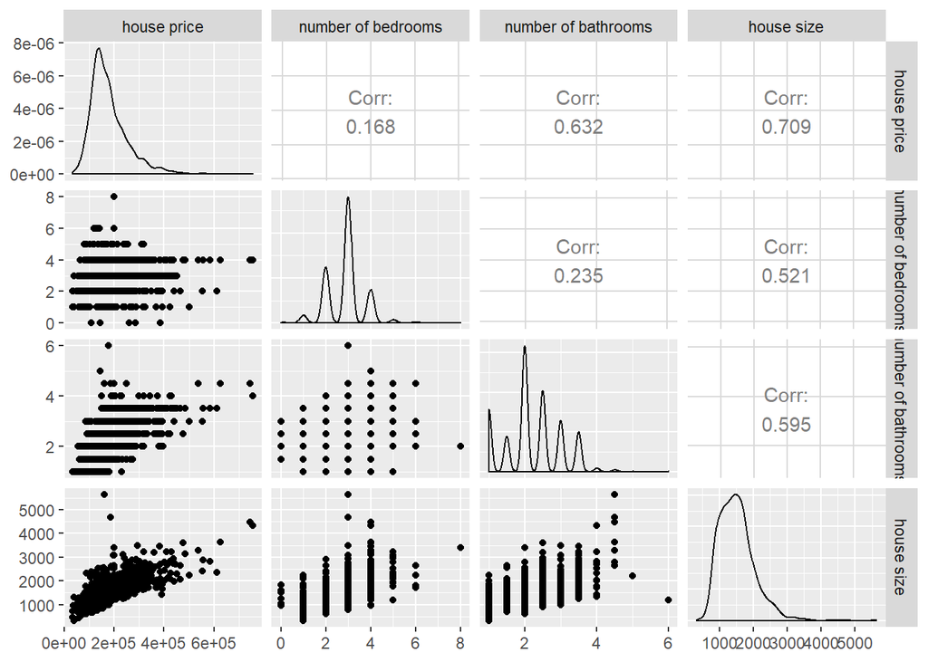

```r
housePriceData$TotalBathroom = housePriceData$BsmtFullBath + (0.5*housePriceData$BsmtHalfBath) + housePriceData$FullBath + (0.5*housePriceData$HalfBath)

ggpairs(housePriceData, columns = c("SalePrice","BedroomAbvGr","TotalBathroom",'GrLivArea') ,columnLabels = c("house price", "number of bedrooms", "number of bathrooms", "house size"))
```

## Report your findings (20 points)

Report the most interesting 2 findings from your analysis.

Finding 1: One finding I think is quite interesting about the data is the relationship between house size and number of bedrooms In my opinion the two would seem to be a linear relationship and therefore highly correlated, However, this is not the case. There is only a correlation of 0.521 which seems significantly lower than I would expect.

Finding 2: I was very surprised to see that there is almost a 4 times stronger correlation between the house price and number of bathrooms rather than house price and number of bedrooms. I would expect these two correlations to be very similar as I would also expect a strong correlation between the two.